# Storm Data Analysis

Anning Chen

January 23, 2016

# Storm Data Analysis between 1950 and 2011

## Synopsis

This analysis will look at storm data from the U.S. National Oceanic and Atmospheric Administration’s (NOAA) storm database[https://d396qusza40orc.cloudfront.net/repdata%2Fdata%2FStormData.csv.bz2] across the United State from 1950 to 2011 and determine the type of events that

1. are most harmful with respect to population health
2. caused most economic damage

From the analysis, we found that

1. tornados cause the most fatalities and injuries by far
2. flood causes the most amount of property damage and drought causes the most crop damage

See below for more detailed analysis and breakdown.

## Loading and Processing the Raw Data

Read in the unzipped repdata-data-StormData.csv file:

```r
stormData <- read.csv('repdata-data-StormData.csv')
dim(stormData)
```

```
## [1] 902297     37
```

There are 902,297 rows and 37 columns in this dataset

Here are the first few lines of the data

```r
head(stormData)
```

```
##   STATE__           BGN_DATE BGN_TIME TIME_ZONE COUNTY COUNTYNAME STATE
## 1       1  4/18/1950 0:00:00     0130       CST     97     MOBILE    AL
## 2       1  4/18/1950 0:00:00     0145       CST      3    BALDWIN    AL
## 3       1  2/20/1951 0:00:00     1600       CST     57    FAYETTE    AL
## 4       1   6/8/1951 0:00:00     0900       CST     89    MADISON    AL
## 5       1 11/15/1951 0:00:00     1500       CST     43    CULLMAN    AL
## 6       1 11/15/1951 0:00:00     2000       CST     77 LAUDERDALE    AL
##    EVTYPE BGN_RANGE BGN_AZI BGN_LOCATI END_DATE END_TIME COUNTY_END
## 1 TORNADO         0                                               0
## 2 TORNADO         0                                               0
## 3 TORNADO         0                                               0
## 4 TORNADO         0                                               0
## 5 TORNADO         0                                               0
## 6 TORNADO         0                                               0
##   COUNTYENDN END_RANGE END_AZI END_LOCATI LENGTH WIDTH F MAG FATALITIES
```

[output cut: 20 more lines]

## Fatalities and Injuries Analysis

There are 2 columns in the stormData dataframe that show impact to population health, namely: fatalities and injuries. We will analyze these columns.

Sum up all the fatalities, get rid of the events with 0 fatalities and sort the list in descending order

```r
fatalities <- aggregate(x = stormData$FATALITIES, by = list(stormData$EVTYPE), sum)
fatalities <- subset(fatalities,x > 0)
fatalities <- fatalities[order(fatalities$x,decreasing = T),]
```

Using the 80-20 rule, we want to see the events that caused 80% of all fatalities and injuries

80% of the total number of fatalities is 12116

```r
.8*sum(fatalities$x)
```

```
## [1] 12116
```

So the 1st 11 events caused more than 80% of fatalities

```r
sum(head(fatalities$x,11))
```

```
## [1] 12287
```

Here are the 11 events that caused the most fatalities

```r
topFatalities <- head(fatalities,11)
topFatalities
```

```
##            Group.1    x
## 834        TORNADO 5633
## 130 EXCESSIVE HEAT 1903
## 153    FLASH FLOOD  978
## 275           HEAT  937
## 464      LIGHTNING  816
## 856      TSTM WIND  504
## 170          FLOOD  470
## 585    RIP CURRENT  368
## 359      HIGH WIND  248
## 19       AVALANCHE  224
## 972   WINTER STORM  206
```

Do the same with injuries

```r
injuries <- aggregate(x = stormData$INJURIES, by = list(stormData$EVTYPE), sum)
injuries <- subset(injuries,x > 0)
injuries <- injuries[order(injuries$x,decreasing = T),]
```

80% of the total number of injuries is 112423

```r
.8*sum(injuries$x)
```

```
## [1] 112422.4
```

The 1st 5 events caued more than 80% of injuries

```r
sum(head(injuries$x,5))
```

```
## [1] 116847
```

But for consistency, just show the same number of events as fatalities

```r
topInjuries <- head(injuries,11)
topInjuries
```

```
##               Group.1     x
## 834           TORNADO 91346
## 856         TSTM WIND  6957
## 170             FLOOD  6789
## 130    EXCESSIVE HEAT  6525
## 464         LIGHTNING  5230
## 275              HEAT  2100
## 427         ICE STORM  1975
## 153       FLASH FLOOD  1777
## 760 THUNDERSTORM WIND  1488
## 244              HAIL  1361
## 972      WINTER STORM  1321
```

Plot of events that caused more than 80% of fatalities and injuries

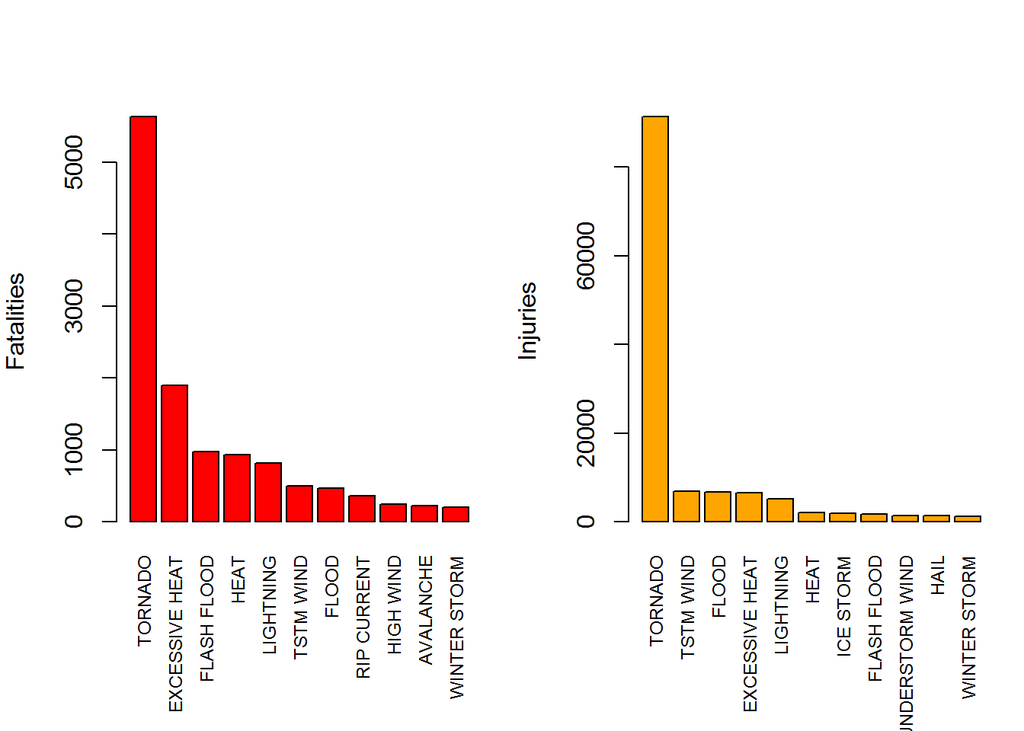

```r
par(mfrow=c(1,2))
par(mar=c(7,4,4,1))
barplot(topFatalities$x,names.arg = topFatalities$Group.1, las = 3, cex.names = .75, col="red", ylab = 'Fatalities')
barplot(topInjuries$x,names.arg = topInjuries$Group.1, las = 3, cex.names = .75, col="orange", ylab='Injuries')
```

## Fatalities and Injuries Results

We can see from the plot above that tornados cause the most fatalities and injuries by far.

## Economic Consequences Analysis

There are 2 columns in the stormData dataFrame that show economic impact, namely: propdmg and cropdmg along with 2 other columns with exp as suffix used for units. The analysis here is essentially the same as for fatalities and injuries but with an additional dollar conversion step.

Here is the propDmgConversion function handling the propDmgExp factors, any exp factor not recognized in the function will cause the value to be 0

```r
unique(stormData$PROPDMGEXP)
```

```
##  [1] K M   B m + 0 5 6 ? 4 2 3 h 7 H - 1 8
## Levels:  - ? + 0 1 2 3 4 5 6 7 8 B h H K m M
```

```r
propDmgConversion <- function(x) {
    if(x['PROPDMGEXP'] == 'K' || x['PROPDMGEXP'] == 'k') {
        multBy <- 1000
    } else if (x['PROPDMGEXP'] == 'M' || x['PROPDMGEXP'] == 'm') {
        multBy <- 1000000
    } else if (x['PROPDMGEXP'] == 'H' || x['PROPDMGEXP'] == 'h') {
        multBy <- 100
    } else if (x['PROPDMGEXP'] == 'B' || x['PROPDMGEXP'] == 'b') {
        multBy <- 1000000000
    } else if (x['PROPDMGEXP'] %in% factor(c(0:8))) {
        multBy <- 10^as.numeric(as.character(x['PROPDMGEXP']))
    } else if (x['PROPDMGEXP'] == '+' || x['PROPDMGEXP'] == '-' || x['PROPDMGEXP'] == '') {
        multBy <- 1
    } else {
        multBy <- 0
    }
    as.numeric(x['PROPDMG'])*multBy
}
```

Convert all propDmg values to a consistent unit and add it as a new column PROPDMGCONV to stormData dataset:

```r
stormData$PROPDMGCONV <- apply(stormData,MARGIN = 1,FUN = propDmgConversion)
```

Do the same for cropDmg values

```r
unique(stormData$CROPDMGEXP)
```

```
## [1]   M K m B ? 0 k 2
## Levels:  ? 0 2 B k K m M
```

```r
cropDmgConversion <- function(x) {
    if(x['CROPDMGEXP'] == 'K' || x['CROPDMGEXP'] == 'k') {
        multBy <- 1000
    } else if (x['CROPDMGEXP'] == 'M' || x['CROPDMGEXP'] == 'm') {
        multBy <- 1000000
    } else if (x['CROPDMGEXP'] == 'H' || x['CROPDMGEXP'] == 'h') {
        multBy <- 100
    } else if (x['CROPDMGEXP'] == 'B' || x['CROPDMGEXP'] == 'b') {
        multBy <- 1000000000
    } else if (x['CROPDMGEXP'] %in% factor(c(0:8))) {
        multBy <- 10^as.numeric(as.character(x['CROPDMGEXP']))
    } else if (x['CROPDMGEXP'] == '+' || x['CROPDMGEXP'] == '-' || x['CROPDMGEXP'] == '') {
        multBy <- 1
    } else {
        multBy <- 0
    }
    as.numeric(x['CROPDMG'])*multBy
}
```

Convert all cropDmg values to a consistent unit and add it as a new column CROPDMGCONV to stormData dataset:

```r
stormData$CROPDMGCONV <- apply(stormData,MARGIN = 1,FUN = cropDmgConversion)
```

sum up all the propDmgConv, get rid of the events with 0 and sort the list in descending order

```r
propDmgConv <- aggregate(x = stormData$PROPDMGCONV, by = list(stormData$EVTYPE), sum)
propDmgConv <- subset(propDmgConv,x > 0)
propDmgConv <- propDmgConv[order(propDmgConv$x,decreasing = T),]
```

See that the top 10 ten events cause more than 80% of all propDmg, so just look at these 10 events

```r
.8*sum(propDmgConv$x)
```

```
## [1] 342579895014
```

```r
sum(head(propDmgConv$x,10))
```

```
## [1] 378323161081
```

```r
topPropDmg <- head(propDmgConv,10)
```

sum up all the cropDmgConv, get rid of the events with 0 and sort the list in descending order

```r
cropDmgConv <- aggregate(x = stormData$CROPDMGCONV, by = list(stormData$EVTYPE), sum)
cropDmgConv <- subset(cropDmgConv,x > 0)
cropDmgConv <- cropDmgConv[order(cropDmgConv$x,decreasing = T),]
```

See that the top 10 ten events cause more than 80% of all cropDmg, so just look at these 10 events

```r
.8*sum(cropDmgConv$x)
```

```
## [1] 39283353745
```

```r
sum(head(cropDmgConv$x,10))
```

```
## [1] 41870220323
```

```r
topCropDmg <- head(cropDmgConv,10)
```

Plot of events that caused more than 80% of propDmg and cropDmg

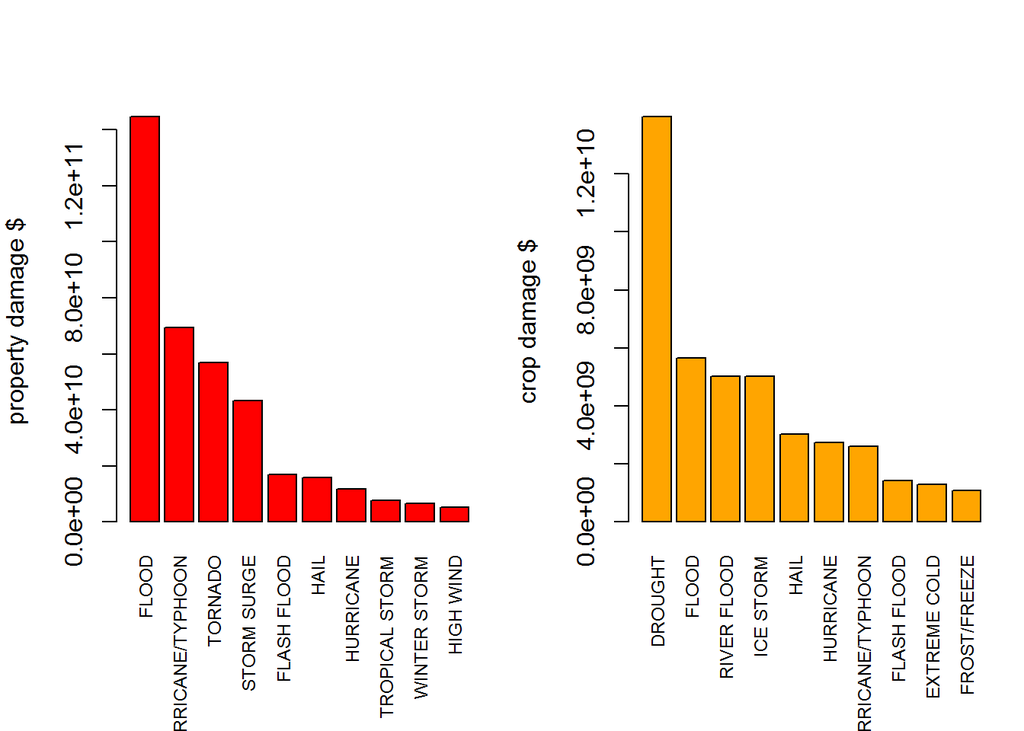

```r
par(mfrow=c(1,2))
par(mar=c(7,4,4,1))
barplot(topPropDmg$x,names.arg = topPropDmg$Group.1, las = 3, cex.names = .75, col="red", ylab = 'property damage $')
barplot(topCropDmg$x,names.arg = topCropDmg$Group.1, las = 3, cex.names = .75, col="orange", ylab='crop damage $')
```

## Economic Consequences Results

We can see that flood causes the most amount of property damage and drought causes the most crop damage.